# Frog Bioinformatics MSc Pathogen Evolution

Xav Harrison

2022-11-01

# 1 INTRODUCTION

In this course, we’ll learn how to:

```
* Process raw Illumina sequencing reads of 16S amplicon data, including data QC, and sequence variant calling
* Quantify traits of microbial community structure, including metrics of alpha diversity and beta diversity
* Fit models to microbial community data to examine how community structure may covary with host life history traits of interest
* Report statistics derived from these analyses in manuscripts
* Make and export some appealing visualisations of microbial communities and how they differ between treatments / host traits.
```

## 1.1 Data and Study Species

We’re going to be looking at a dataset of skin bacterial communities, sampled from wild Phofung River frog (*Amietia hymenopus*) tadpoles in the Drakensberg mountains, South Africa. We have data from *29 individuals from two sites*.

We have been tasked with i) characterising the skin microbiome diversity/composition of this species, and ii) looking for systematic associations between skin microbiome and infection with the lethal fungal pathogen *Batrachochytrium dendrobatidis* (Bd).

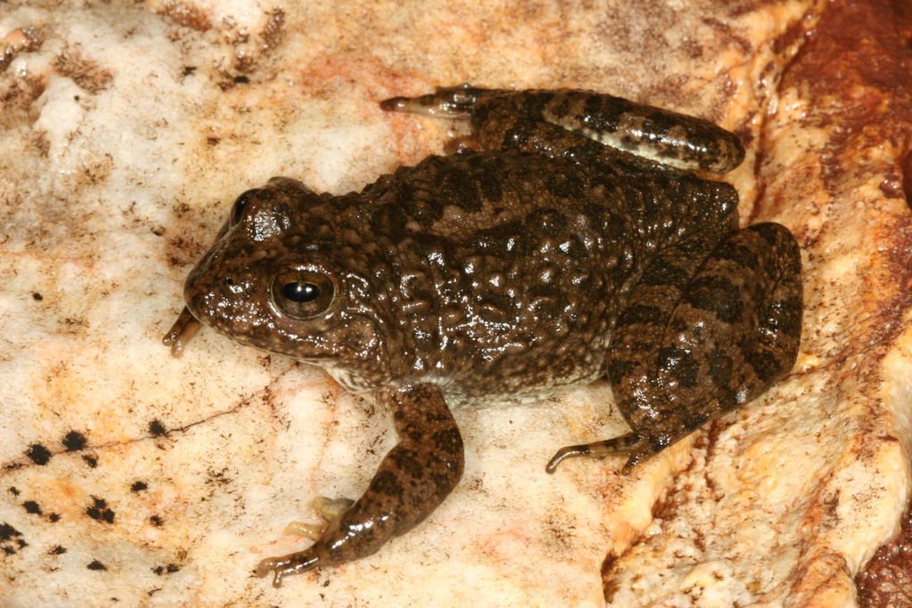

Adult Phofung River frog © Louis du Preez

We have been given the raw sequencing files of the v4 region of the 16S rRNA gene from a paired-end 300bp sequencing run on the Illumina Miseq (V3 Chemistry).

There’s also a no-template negative control, and a mock community.  
The **no-template control** allows us to quantify background levels of contamination in the sequencing run, including bacterial contamination in the reagents referred to as the ‘kitome’ Fun fact! Every reagent / DNA extraction kit / PCR mastermix / sequencing cartridge will have some contamination in it, and different batches of the same reagent can often have unique microbiome profiles! See the [blog](http://blog.mothur.org/2014/11/12/TheKitome/) by Pat Schloss and [paper](https://bmcbiol.biomedcentral.com/articles/10.1186/s12915-014-0087-z)

The **mock community** is a uniquely barcoded sample containing an artificially-created community of bacteria with known (often full length) 16S sequence data. Sequencing this community alongside our samples allows us to assess whether i) our estimated number of unique sequences (roughly corresponding to dataset-level alpha diversity) is correct; and ii) whether the actual sequences themselves are correct or contain errors. You can imagine you could have a correct estimate of the unique number of sequences, but the sequences themselves might be very error-prone. Or your run may have recovered the correct sequences but also generated a lot of noise, inflating the total number of seqs in the data set. By estimating these two quantities, we can be confident than any actual alpha & beta diversity differences among samples are real and not artefacts generated by the messy sequencing. It is vital that you always include a mock community in your library preps.

We’ll tackle these data in two sections:

Part 1 (this section) will deal with the raw-read processing and bioinformatics. Part 2 will deal with statistics and analyses.

# 2 PART 1 BIOINFORMATICS

## 2.1 Libraries

These are the libraries we will need for this workflow.

```r
#Calling of Amplicon Sequence Variants (ASVs)
    library(dada2)
    packageVersion('dada2')
```

```
## [1] '1.24.0'
```

```r
#Accessory Packages
  #library(ips) # tree building
  library(ape) # more trees
  library(openssl) #reproducible sequence naming
#Downstream Statistics
  library(phyloseq)
```

## 2.2 File Path and Data

Now we need to tell DADA2 where to look for the data files, using the ‘set path command’. The path below will need to be changed to the folder where you stored your copy of the training data. The nice thing about R Studio is that you can use ‘Tab Complete’ to navigate to your folder.

*YOU WILL NEED TO CHANGE THIS FILE PATH*

```r
  #Specify File Path
    path <- "~/Desktop/MSc Pathogen Evolution Bioinformatics/" # CHANGE ME to the directory containing the fastq files after unzipping.
    list.files(path)
```

```
##  [1] "10544_Bacterial_Mock_2_S44_R1_001_cuta.fastq.gz"
##  [2] "10544_Bacterial_Mock_2_S44_R2_001_cuta.fastq.gz"
##  [3] "10544_Nc2_S41_R1_001_cuta.fastq.gz"
##  [4] "10544_Nc2_S41_R2_001_cuta.fastq.gz"
##  [5] "10544_P1F1_S45_R1_001_cuta.fastq.gz"
##  [6] "10544_P1F1_S45_R2_001_cuta.fastq.gz"
##  [7] "10544_P1F10_S54_R1_001_cuta.fastq.gz"
##  [8] "10544_P1F10_S54_R2_001_cuta.fastq.gz"
##  [9] "10544_P1F11_S55_R1_001_cuta.fastq.gz"
## [10] "10544_P1F11_S55_R2_001_cuta.fastq.gz"
## [11] "10544_P1F12_S56_R1_001_cuta.fastq.gz"
## [12] "10544_P1F12_S56_R2_001_cuta.fastq.gz"
## [13] "10544_P1F13_S57_R1_001_cuta.fastq.gz"
## [14] "10544_P1F13_S57_R2_001_cuta.fastq.gz"
## [15] "10544_P1F14_S58_R1_001_cuta.fastq.gz"
```

[output cut: 61 more lines]

This should show you a long list of all the files. Now we’ll extract the file names and sort them so that paired F and R reads for the same sample occur in the same order.

Then we’ll use a function that can strip the sample names out of the read names from the instrument. These are important because they will be used to match up the sequencing reads to our sample metadata later.

```r
  ## Forward and reverse fastq filenames
    fnFs <- sort(list.files(path, pattern="_R1_001_cuta.fastq", full.names = TRUE))
    fnRs <- sort(list.files(path, pattern="_R2_001_cuta.fastq", full.names = TRUE))

  # Extract sample names, 2nd element of name
      #have to add extra string here to prevent duplicate names
    sample.names <- paste(sapply(strsplit(basename(fnFs), "_"), `[`, 2),sapply(strsplit(basename(fnFs), "_"), `[`, 4),sep="_")

    #Scrub Trailing R1
      sample.names2<- gsub("_R1$","",sample.names)

    #Check for Duplicates
      sample.names[which(duplicated(sample.names))]
```

```
## character(0)
```

```r
      fnFs[which(duplicated(sample.names))]
```

```
## character(0)
```

## 2.3 Quality Profiles

Now that we’ve done all the file admin, we can use some of the built in functions in DADA2 to inspect our raw data to assess the quality of the sequencing data.

### 2.3.1 Forward Read

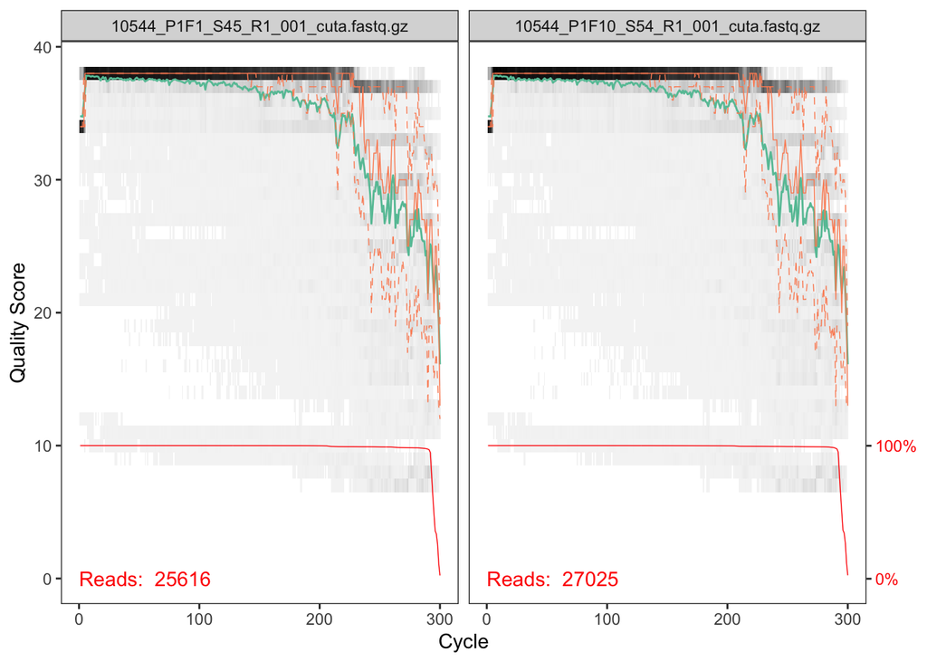

```r
  #Quality Profiles
    plotQualityProfile(fnFs[3:4]) #Forwards reasonable, suggest trim 275 to start with (~Q27), 250 for Q30
```

### 2.3.2 Reverse Reads

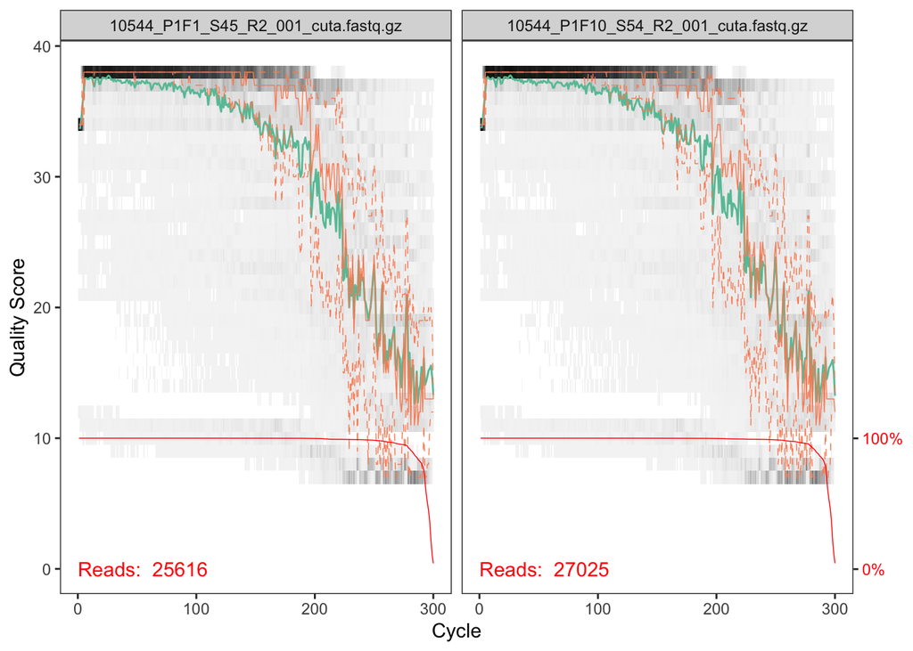

```r
    plotQualityProfile(fnRs[3:4]) #Worse as expected, 250bp = Q25, 200bp for Q30
```

## 2.4 Filter and Trim

What do we do with these data? We can use our inspection of raw read qualities to make decisions about i) trimming the reads to get rid of low quality sequences at the ends of the reads and ii) filter some reads out that fail to meet a certain minimum quality

First, we set up some folders that will act as a home to our filtered and trimmed reads:

```r
######## FILTER AND TRIM

  # Place filtered files in filtered/ subdirectory
    filtFs <- file.path(path, "filtered", paste0(sample.names, "_F_filt.fastq.gz"))
    filtRs <- file.path(path, "filtered", paste0(sample.names, "_R_filt.fastq.gz"))
    names(filtFs) <- sample.names2
    names(filtRs) <- sample.names2
```

Next, we filter and trim the reads based on some quality rules. The following is a very important bit of code, and will take a while to run.

The first 4 arguments **(fnFs, filtFs, fnRs, filtRs)** contain the paths to read files in [fnFs,fnRs] and where to store the filtered results [filtFs,filtRs] that we just created.

**MaxN** : The total number of uncalled bases ’N’s to allow. Default 0, don’t change it.

**maxEE** : The maximum number of ‘expected errors’ to allow in a read, allowing you to specify separate values for c(F,R) reads. This is an alternative to simply filtering based on average Q score of the read, which can be problematic if it’s skewed by a few high quality basecalls that mask the junk lurking within. Keeping it at 2 per F and R read for a 250bp amplicon seems reasonable.

**truncQ**: Truncate reads at the point where a base with this Q score is encountered. Default 2.

There’s a [plethora of options](https://rdrr.io/bioc/dada2/man/filterAndTrim.html) you can tweak with this function, if you’re interested. Have a look.

```r
  #FILTER AND TRIM
    out <- filterAndTrim(fnFs, filtFs, fnRs, filtRs, truncLen=c(275,200),
    maxN=0, maxEE=c(2,2), truncQ=2, rm.phix=TRUE,
    compress=TRUE, multithread=TRUE,trimLeft = c(20,20))
```

DADA2 has now made a nice summary of the how many reads have survived our filtering and trimming step. Have a look:

```r
    #Inspect
      head(out)
```

```
##                                                 reads.in reads.out
## 10544_Bacterial_Mock_2_S44_R1_001_cuta.fastq.gz    25338     21085
## 10544_Nc2_S41_R1_001_cuta.fastq.gz                   292       237
## 10544_P1F1_S45_R1_001_cuta.fastq.gz                25616     21740
## 10544_P1F10_S54_R1_001_cuta.fastq.gz               27025     23191
## 10544_P1F11_S55_R1_001_cuta.fastq.gz               26412     20444
## 10544_P1F12_S56_R1_001_cuta.fastq.gz               24587     19459
```

If you wanted, you could play around with the parameters above and see what effect it has on the reads making the cut. If you do, remember to call the new ‘out’ object something different. So we might decide to be less brutal with our reverse cull. If the first filter_and_trim was very slow on your computer, you might want to rethink running this step.

```
out_rev220<-filterAndTrim(fnFs, filtFs, fnRs, filtRs, truncLen=c(240,220),
                       maxN=0, maxEE=c(2,2), truncQ=2, rm.phix=TRUE,
                       compress=TRUE, multithread=TRUE)
```

## 2.5 Error Rates

Ok, so now we have filtered our data to a quality that we’re happy with so to try and minimise sequencing errors.

The following [taken from the original DADA2 paper][https://pdfs.semanticscholar.org/88b2/f20b82d9432d96832f22ef34abc1ed17526b.pdf] explains the DADA2 approach of learning error rates from the data is so powerful:

> Currently, errors in Illumina-sequenced amplicon data are most often addressed by filter- ing low quality reads and constructing Operational Taxonomic Units (OTUs): clusters of sequences that differ by less than a fixed dissimilarity threshold (typically 3%) within which sequence variation is ignored [9, 10, 11]. Lumping similar sequences together reduces the rate at which errors are misinterpreted as biological variation, but OTUs under-utilize the quality of modern sequencing by precluding the possibility of resolving fine-scale (or strain-level) variation [7, 12, 13, 14, 15].

So DADA2’s method of calling ‘Amplicon Sequence Variants (ASVs)’ differes from Operational Taxonomic Unit (OTU) approaches that cluster sequences to a fixed simialrity threshold (usually 97% similarity) to try and minimise errors. So now we’re going to estimate the rates of sequencing error in our data, and use those errors to separate biological signal (real sequences) from noise (residual sequencing errors). DADA2 ‘denoises’ the sequences (DADA = Divsive Amplicon Denoising Algorithm) to give you a dataset of (hopefully) ‘exact sequence variants’.

```r
######### ERROR RATES
      errF <- learnErrors(filtFs, multithread=TRUE)
```

```
## 105076065 total bases in 412063 reads from 21 samples will be used for learning the error rates.
```

```r
      errR <- learnErrors(filtRs, multithread=TRUE)
```

```
## 101976120 total bases in 566534 reads from 28 samples will be used for learning the error rates.
```

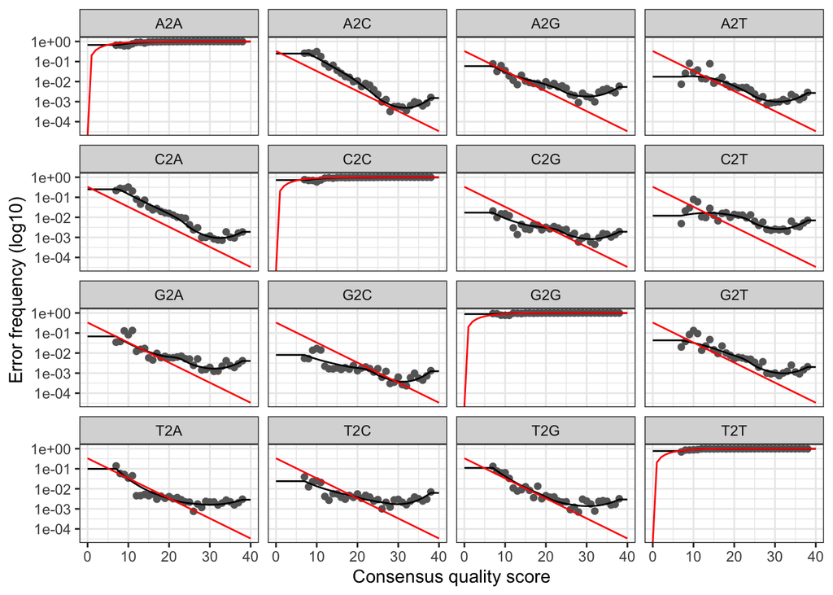

```r
      plotErrors(errF, nominalQ=TRUE)
```

**How does DADA2 estimate error rates?** The short answer is “it’s complicated”. But a slightly longer answer is that DADA2 does some fancy modelling to reconstruct expected genotypes, and then assesses two key probability traits to work out whether a sequence in the dataset is real or not. The first looks at the relative abundance of sequences, and broadly accepts sequences that are very high abundance as likely true sequences (i.e. if multiple independent reads have all recovered the same sequence, it’s probably real). The second looks at the distance between a sequence under consideration and calculates if it’s too far away from other inferred ‘true sequences’ to be an error. Put another way, a sequence differing by only one base from a true sequence could very well be an error. One differing by 10 bases likely isn’t. The model optimises these two traits iteratively until the model converges. Like all elegant mathematics, it looks to be witchcraft on first inspection.

You can [read about the details here](https://www.nature.com/articles/nmeth.3869#methods) if you’re interested.

Now we can inspect the error profiles. These error rates are the transition probabilities for individual dyads of bases (y axis) by quality score (x axis). As you might expect, the probability of commiting an error declines as the Q score of the base call increases - all the slopes are negative. The diagonals are all flat because the bases aren’t changing i.e. A->A. The black line is the error model fitted to the data (black dots, the actual estimates error rate) - we can assess how robust the error rate model is if the black line does a good job of tracking the points. DADA2 uses this model to quantify the likelihood of a particular base call of a given quality score being an error, and will adjust our raw sequences in the next step.

**YOUR DATA** Like above, this step uses only a subset of the data. If the error model looks a poor fit (black line does not track data points) you can tell DADA2 to increase the amount of data it uses to learn the error model.

## 2.6 Denoising Raw Sequences Using Error Rates

So we have filtered sequence data, and an error model. It’s time to infer our ‘exact’ Amplicon Sequence Variants (ASVs).

```r
######### SAMPLE INFERENCE
      dadaFs <- dada(filtFs, err=errF, multithread=TRUE)
```

```
## Sample 1 - 21085 reads in 4190 unique sequences.
## Sample 2 - 237 reads in 131 unique sequences.
## Sample 3 - 21740 reads in 7525 unique sequences.
## Sample 4 - 23191 reads in 7377 unique sequences.
## Sample 5 - 20444 reads in 8781 unique sequences.
## Sample 6 - 19459 reads in 5838 unique sequences.
## Sample 7 - 21273 reads in 7254 unique sequences.
## Sample 8 - 18948 reads in 8197 unique sequences.
## Sample 9 - 21926 reads in 8441 unique sequences.
## Sample 10 - 20607 reads in 6536 unique sequences.
## Sample 11 - 19653 reads in 6663 unique sequences.
## Sample 12 - 17174 reads in 7559 unique sequences.
## Sample 13 - 22550 reads in 8789 unique sequences.
## Sample 14 - 22844 reads in 8669 unique sequences.
## Sample 15 - 22682 reads in 9126 unique sequences.
## Sample 16 - 23379 reads in 9694 unique sequences.
## Sample 17 - 12837 reads in 4672 unique sequences.
## Sample 18 - 19422 reads in 4158 unique sequences.
## Sample 19 - 20678 reads in 11302 unique sequences.
## Sample 20 - 21850 reads in 8075 unique sequences.
## Sample 21 - 20084 reads in 9726 unique sequences.
## Sample 22 - 24149 reads in 8435 unique sequences.
## Sample 23 - 22241 reads in 8586 unique sequences.
## Sample 24 - 21802 reads in 7379 unique sequences.
## Sample 25 - 23604 reads in 9019 unique sequences.
## Sample 26 - 20206 reads in 7592 unique sequences.
## Sample 27 - 22021 reads in 8106 unique sequences.
## Sample 28 - 20448 reads in 10735 unique sequences.
## Sample 29 - 22270 reads in 9790 unique sequences.
## Sample 30 - 21819 reads in 9002 unique sequences.
## Sample 31 - 21200 reads in 8127 unique sequences.
```

```r
      dadaRs <- dada(filtRs, err=errR, multithread=TRUE)
```

```
## Sample 1 - 21085 reads in 3005 unique sequences.
## Sample 2 - 237 reads in 116 unique sequences.
## Sample 3 - 21740 reads in 7219 unique sequences.
## Sample 4 - 23191 reads in 6694 unique sequences.
## Sample 5 - 20444 reads in 7306 unique sequences.
## Sample 6 - 19459 reads in 5306 unique sequences.
## Sample 7 - 21273 reads in 6468 unique sequences.
## Sample 8 - 18948 reads in 6446 unique sequences.
## Sample 9 - 21926 reads in 7924 unique sequences.
## Sample 10 - 20607 reads in 6565 unique sequences.
## Sample 11 - 19653 reads in 6806 unique sequences.
## Sample 12 - 17174 reads in 5586 unique sequences.
## Sample 13 - 22550 reads in 8940 unique sequences.
## Sample 14 - 22844 reads in 7953 unique sequences.
## Sample 15 - 22682 reads in 7964 unique sequences.
## Sample 16 - 23379 reads in 9093 unique sequences.
## Sample 17 - 12837 reads in 2998 unique sequences.
## Sample 18 - 19422 reads in 4319 unique sequences.
## Sample 19 - 20678 reads in 10852 unique sequences.
## Sample 20 - 21850 reads in 8248 unique sequences.
## Sample 21 - 20084 reads in 8865 unique sequences.
## Sample 22 - 24149 reads in 8450 unique sequences.
## Sample 23 - 22241 reads in 8445 unique sequences.
## Sample 24 - 21802 reads in 7886 unique sequences.
## Sample 25 - 23604 reads in 8690 unique sequences.
## Sample 26 - 20206 reads in 7152 unique sequences.
## Sample 27 - 22021 reads in 8160 unique sequences.
## Sample 28 - 20448 reads in 10575 unique sequences.
## Sample 29 - 22270 reads in 9534 unique sequences.
## Sample 30 - 21819 reads in 8423 unique sequences.
## Sample 31 - 21200 reads in 7799 unique sequences.
```

## 2.7 Merge Denoised F and R pairs into Contigs

Easy peasy! Now our F and R reads have each been denoised using read-specific error models to what we hope is biologically relevant sequence variation!

The next step is to join F and R denoised, dereplicated reads into contigs of the ~250bp consensus sequence we’re actually interested in. Note the contig size here will change dependign on your primer sets and read chemistry (V2/V3 MISeq, 150bp PE NovaSeq etc) for different data

```r
######### MERGE ERROR-CORRECTED PAIRED READS
      mergers <- mergePairs(dadaFs, filtFs, dadaRs, filtRs, verbose=TRUE)
```

```
## 20576 paired-reads (in 36 unique pairings) successfully merged out of 20948 (in 102 pairings) input.
```

```
## 195 paired-reads (in 16 unique pairings) successfully merged out of 221 (in 21 pairings) input.
```

```
## 19100 paired-reads (in 306 unique pairings) successfully merged out of 20312 (in 566 pairings) input.
```

```
## 21532 paired-reads (in 393 unique pairings) successfully merged out of 22249 (in 557 pairings) input.
```

```
## 17585 paired-reads (in 559 unique pairings) successfully merged out of 18995 (in 829 pairings) input.
```

```
## 18038 paired-reads (in 260 unique pairings) successfully merged out of 18542 (in 390 pairings) input.
```

```
## 19463 paired-reads (in 365 unique pairings) successfully merged out of 20102 (in 513 pairings) input.
```

```
## 16520 paired-reads (in 419 unique pairings) successfully merged out of 17589 (in 640 pairings) input.
```

```
## 18850 paired-reads (in 580 unique pairings) successfully merged out of 20065 (in 878 pairings) input.
```

```
## 19415 paired-reads (in 159 unique pairings) successfully merged out of 19694 (in 230 pairings) input.
```

```
## 16730 paired-reads (in 268 unique pairings) successfully merged out of 18239 (in 549 pairings) input.
```

```
## 14294 paired-reads (in 338 unique pairings) successfully merged out of 15792 (in 597 pairings) input.
```

```
## 18864 paired-reads (in 455 unique pairings) successfully merged out of 20777 (in 847 pairings) input.
```

```
## 19584 paired-reads (in 302 unique pairings) successfully merged out of 21336 (in 604 pairings) input.
```

```
## 18815 paired-reads (in 554 unique pairings) successfully merged out of 20727 (in 975 pairings) input.
```

```
## 18830 paired-reads (in 427 unique pairings) successfully merged out of 21500 (in 857 pairings) input.
```

```
## 12168 paired-reads (in 131 unique pairings) successfully merged out of 12443 (in 195 pairings) input.
```

```
## 18677 paired-reads (in 115 unique pairings) successfully merged out of 19044 (in 174 pairings) input.
```

```
## 13616 paired-reads (in 687 unique pairings) successfully merged out of 17327 (in 1413 pairings) input.
```

```
## 18657 paired-reads (in 487 unique pairings) successfully merged out of 20310 (in 815 pairings) input.
```

```
## 15257 paired-reads (in 499 unique pairings) successfully merged out of 17741 (in 969 pairings) input.
```

```
## 21286 paired-reads (in 701 unique pairings) successfully merged out of 23002 (in 1020 pairings) input.
```

```
## 18663 paired-reads (in 512 unique pairings) successfully merged out of 20605 (in 870 pairings) input.
```

```
## 19166 paired-reads (in 344 unique pairings) successfully merged out of 20333 (in 578 pairings) input.
```

```
## 19658 paired-reads (in 492 unique pairings) successfully merged out of 21555 (in 866 pairings) input.
```

```
## 17336 paired-reads (in 472 unique pairings) successfully merged out of 18581 (in 762 pairings) input.
```

```
## 18610 paired-reads (in 326 unique pairings) successfully merged out of 20223 (in 662 pairings) input.
```

```
## 13833 paired-reads (in 572 unique pairings) successfully merged out of 17461 (in 1182 pairings) input.
```

```
## 16901 paired-reads (in 633 unique pairings) successfully merged out of 19669 (in 1187 pairings) input.
```

```
## 17159 paired-reads (in 619 unique pairings) successfully merged out of 19523 (in 1095 pairings) input.
```

```
## 17402 paired-reads (in 675 unique pairings) successfully merged out of 19488 (in 1077 pairings) input.
```

## 2.8 Summarise Sequences Across All Samples

Now we inspect the contigs we’ve made to look at the distribution of sequence lengths. Rememebr that we’re expecting amplicons of around 250bp

```r
######### MAKE SEQUENCE TABLE
      seqtab <- makeSequenceTable(mergers)
      dim(seqtab)
```

```
## [1]   31 6020
```

```r
    #LENGTH DISTRIBUTION
      table(nchar(getSequences(seqtab)))
```

```
##
##  255  256  257  258  259  260  263  264  265  266  271  273  274  276  289  290
## 5948   12    5    4    6    1    2    3    2    1    1    2    1    1    1    1
##  294  298  305  316  322  337  360  361  364  384  409  410  411  412  414  415
##    1    1    1    1    1    1    3    1    1    1    3    1    1    1    1    3
##  416  417  418  419  420
##    1    1    1    3    1
```

### 2.8.1 Further Filtering Based on Length

It looks like we’ve got a lot of sequences at the expected length. (~240-260). But also some sequences that are much longer than expected >300bp and low abundance, some of them singletons.We probably don’t want these as they may be the result of non-specific priming at non-target sites (i.e. somewhere that’s not the v4 16S amplicon). We can trim these as follows:

```r
    #How many over 260 bp?
      sizedist<-data.frame(t(table(nchar(getSequences(seqtab)))))
      filtseqs<-sum(sizedist[,3][which(as.numeric(as.character(sizedist[,2]))>260)])
      (filtseqs/sum(sizedist[,3]) )*100
```

```
## [1] 0.730897
```

<1%, so we can confidently boot them out.

```r
    #Trimming Step?
      seqtab2 <- seqtab[,nchar(colnames(seqtab)) %in% 250:260]
```

## 2.9 Remove Chimeras

The final step is to identify and remove chimeras. One of the pitfalls of next-gen sequencing that uses sequencing-by-synthesis methods is that there millions of PCRs all occurring simultaneously, and sometimes two real sequences will hybridise to form a novel chimeric sequence that isn’t real. As per the DADA2 workflow: “Chimeric sequences are identified if they can be exactly reconstructed by combining a left-segment and a right-segment from two more abundant “parent” sequences.””

Remember that we’re using *seqtab2* here - the trimmed one that removed non-target length sequences.

```r
########### REMOVE CHIMERAS
      set.seed(1000)
      seqtab.nochim <- removeBimeraDenovo(seqtab2, method="consensus", multithread=TRUE, verbose=TRUE)
```

```
## Identified 43 bimeras out of 5976 input sequences.
```

```r
## How many Chimeras?
      dim(seqtab2)[2]-dim(seqtab.nochim)[2] # ~ 43 bimeras
```

```
## [1] 43
```

```r
# How Many Reads Did We Retain?
        sum(seqtab.nochim)/sum(seqtab2) #99.2% reads retained
```

```
## [1] 0.9921035
```

## 2.10 Tracking Reads Through The PipeLine

DADA2 will tell us how many chimeric sequences it found out of the total. And that’s the last step in our quality control for the sequencing portion of the workflow. Now we can generate a handy per-sample summary that tracks reads-per-sample throughout each step we’ve performed in this workflow.

```r
############# PIPELINE READ TRACKING
      getN <- function(x) sum(getUniques(x))
      track <- cbind(out, sapply(dadaFs, getN), sapply(dadaRs, getN), sapply(mergers, getN), rowSums(seqtab.nochim))
      # If processing a single sample, remove the sapply calls: e.g. replace sapply(dadaFs, getN) with getN(dadaFs)
      colnames(track) <- c("input", "filtered", "denoisedF", "denoisedR", "merged", "nonchim")
      rownames(track) <- sample.names
      head(track)
```

```
##             input filtered denoisedF denoisedR merged nonchim
## Bacterial_2 25338    21085     21018     20988  20576   19804
## Nc2_R1        292      237       225       229    195     195
## P1F1_R1     25616    21740     20615     20855  19100   18858
## P1F10_R1    27025    23191     22521     22626  21532   21125
## P1F11_R1    26412    20444     19396     19604  17585   17152
## P1F12_R1    24587    19459     18767     18897  18038   17927
```

## 2.11 Taxonomic Assignment

Now that we’ve adjusted our sequences for errors, and removed chimeras, we can assign taxonomy to them. To do this, we need a reference database. The maintainers of DADA2 format some of the most commonly used databases, SILVA and RDP, for use with DADA2. [They are kept here](https://benjjneb.github.io/dada2/training.html)

We’ll use the most recent version of the SILVA database. You’ll need to tell DADA2 where to find it. Assigning taxonomy is as easy as the following. But it will take a long time to do for this small subset of a full sequencing run, and even longer for a full run. Feel free to take a break whilst this runs!

NOTE: If taxonomic assignment seems poor, it can be useful to compare assignments across databases (e.g. RDP vs SILVA). Again, just create a new R object (e.g. taxa_rdp) and use a different database, allowing comparison of end results.

### 2.11.1 Kingdom to Genus

```r
# Random Number Seed for Reproducibility
    set.seed(100)

##ASSIGN TAXONOMY
      taxa <- assignTaxonomy(seqtab.nochim, "~/Desktop/MSc Pathogen Evolution Bioinformatics/Taxonomy/silva_nr99_v138.1_train_set.fa", multithread=TRUE)
      head(unname(taxa))
```

```
##      [,1]       [,2]             [,3]                  [,4]
## [1,] "Bacteria" "Proteobacteria" "Gammaproteobacteria" "Pseudomonadales"
## [2,] "Bacteria" "Proteobacteria" "Gammaproteobacteria" "Burkholderiales"
## [3,] "Bacteria" "Proteobacteria" "Gammaproteobacteria" "Burkholderiales"
## [4,] "Bacteria" "Proteobacteria" "Gammaproteobacteria" "Burkholderiales"
## [5,] "Bacteria" "Proteobacteria" "Gammaproteobacteria" "Burkholderiales"
## [6,] "Bacteria" "Bacteroidota"   "Bacteroidia"         "Flavobacteriales"
##      [,5]               [,6]
## [1,] "Pseudomonadaceae" "Pseudomonas"
## [2,] "Comamonadaceae"   "Polaromonas"
## [3,] "Oxalobacteraceae" "Janthinobacterium"
## [4,] "Comamonadaceae"   "Rhodoferax"
## [5,] "Comamonadaceae"   NA
## [6,] "Weeksellaceae"    "Chryseobacterium"
```

### 2.11.2 Risky Taxonomic Bonus: Species ID

We can also try and assign species-level taxonomy to some sequences. As you might guess, this is very difficult to do from a 250bp sequence of a highly conserved marker gene like 16S rRNA, and many people has a problem with it. But, for very well characterised systems, normally model systems like Drosophila or lab mice, you might get lucky with some species-level classification.

```r
      #Species
      taxa2 <- addSpecies(taxa, "~/Desktop/MSc Pathogen Evolution Bioinformatics/Taxonomy/silva_species_assignment_v138.1.fa")
        head(unname(taxa2))
```

```
##      [,1]       [,2]             [,3]                  [,4]
## [1,] "Bacteria" "Proteobacteria" "Gammaproteobacteria" "Pseudomonadales"
## [2,] "Bacteria" "Proteobacteria" "Gammaproteobacteria" "Burkholderiales"
## [3,] "Bacteria" "Proteobacteria" "Gammaproteobacteria" "Burkholderiales"
## [4,] "Bacteria" "Proteobacteria" "Gammaproteobacteria" "Burkholderiales"
## [5,] "Bacteria" "Proteobacteria" "Gammaproteobacteria" "Burkholderiales"
## [6,] "Bacteria" "Bacteroidota"   "Bacteroidia"         "Flavobacteriales"
##      [,5]               [,6]                [,7]
## [1,] "Pseudomonadaceae" "Pseudomonas"       NA
## [2,] "Comamonadaceae"   "Polaromonas"       NA
## [3,] "Oxalobacteraceae" "Janthinobacterium" NA
## [4,] "Comamonadaceae"   "Rhodoferax"        NA
## [5,] "Comamonadaceae"   NA                  NA
## [6,] "Weeksellaceae"    "Chryseobacterium"  NA
```

### 2.11.3 Evaluating Assignment Success

Here we can calculate how many successful assignments there were at each level of taxonomy. Because DADA2 assigned ‘NA’ for unassigned taxonomy, we can simply ask how many values in each column are not NA.

```r
apply(taxa2,2,function(x)mean(!is.na(x)))
```

```
##    Kingdom     Phylum      Class      Order     Family      Genus    Species
## 1.00000000 0.98617900 0.95971684 0.89364571 0.73167032 0.43013652 0.02646216
```

## 2.12 Tidy Up The Sequence Names

By default DADA2 will name the sequences will their full ~250bp gene sequences, which is good for keeping all the data together but a pain for easy visualisation of tables. So we first store the raw sequences, then rename the taxonomy object with a short reproducible hexadecimal code string, meaning if we want we can recover the sequences from that code. This is more robust than renaming them sequentially ‘ASV1, ASV2,…’ etc

```r
################ Sort Out Names

    # Extract sequences (to save them)
        seqs <- Biostrings::DNAStringSet(getSequences(seqtab.nochim))

    # New names
        asv_new <- openssl::md5(getSequences(seqtab.nochim))

      # Put in the new names for all objects
        colnames(seqtab.nochim) <- asv_new
        names(seqs) <- asv_new
        rownames(taxa) <- asv_new
```

### 2.12.1 Check The Sequence Naming is Reproducible

```r
bout1<-openssl::md5(getSequences(seqtab.nochim)[1:10])
bout2<-openssl::md5(getSequences(seqtab.nochim)[1:10])
all.equal(bout1,bout2)
```

```
## [1] TRUE
```

## 2.13 Building a Phylogenetic Tree of Our Sequences

To use metrics of community structure like UniFrac, you need a phylogenetic tree of your sequences. If you wanted to build a tree with all of your sequences, you could run this code here. We wont run this step in this tutorial, because it involves handing off the sequences to the external programs MAFFT and FastTree. There are workflows online for building trees directly in R using the packages *DECIPHER* and *phangorn* but they are sloooowww. I would always recommend using FastTree for your own data.

### 2.13.1 Gather Sequences and Hand off To MAFFT and FastTree (externally)

```r
 ################ PHYLOGEENTIC TREE


    # # USe IPS package to Align using MAFFT external program
        #seq.dna <- as.DNAbin(seqs)
        #frogseq_align <- mafft(seq.dna,exec='/usr/local/bin/mafft')
        #image(frogseq_align)

      #Check Length Distribution (any much longer or shorter than expected?)
        #table(nchar(as.character(seqs)))

      #Any With Unknown Phylum? Likely Junk
        #dim(taxa[is.na(taxa[, "Phylum"]), ])
    #
    #   #Write Alignment to file
    #write.fas(frogseq_align, file = "frog_mscpathogenevolution_alignment.fasta")
```

### 2.13.2 Read in Tree Computed By FastTree

WE can read in a precomputed Tree using the data above that have already been through FastTree

```r
#Read in The Tree
            tree <- read.tree("~/Desktop/MSc Pathogen Evolution Bioinformatics/frog_mscpathogen_tree")

    #Any Archaea to root with
        archaea_asvs <- rownames(taxa)[taxa[, "Kingdom"] == "Archaea"][1]

      #ROOT
        tree <- root(tree, outgroup=archaea_asvs, resolve.root=TRUE)
```

## 2.14 Evaluating Sequencing Accuracy Using a Mock Community

### 2.14.1 How Many Sequences In The Mock?

This community contains 3 easy-to-lyse Gram Negative Bacteria, and 5 tough-to-lyse Gram positive Bacteria. So we’re expecting 8 unique sequences here. There are also 2 yeasts in this mock community, which we dont expect to turn up here.

```r
############### MOCK COMMUNITY ACCURACY
      unqs.mock <- seqtab.nochim[grep("Bacterial",rownames(seqtab.nochim)),]
      unqs.mock_sort <- sort(unqs.mock[unqs.mock>0], decreasing=TRUE) # Drop ASVs absent in the Mock
      cat("DADA2 inferred", length(unqs.mock_sort), "sample sequences present in the Mock community.\n") #
```

```
## DADA2 inferred 8 sample sequences present in the Mock community.
```

### 2.14.2 How Good Was Our Taxonomic Assignment?

Theoretical Composition Based on Genomic DNA: PROKARYOTES: Listeria monocytogenes - 12% Pseudomonas aeruginosa - 12% Bacillus subtilis - 12% Escherichia coli - 12% Salmonella enterica - 12% Lactobacillus fermentum - 12% Enterococcus faecalis - 12% Staphylococcus aureus - 12% EUKARYOTES: Saccharomyces cerevisiae - 2% Cryptococcus neoformans - 2%.

```r
      unname(taxa2[which(unname(unqs.mock)>0),])
```

```
##      [,1]       [,2]             [,3]                  [,4]
## [1,] "Bacteria" "Firmicutes"     "Bacilli"             "Bacillales"
## [2,] "Bacteria" "Firmicutes"     "Bacilli"             "Staphylococcales"
## [3,] "Bacteria" "Firmicutes"     "Bacilli"             "Lactobacillales"
## [4,] "Bacteria" "Firmicutes"     "Bacilli"             "Lactobacillales"
## [5,] "Bacteria" "Proteobacteria" "Gammaproteobacteria" "Enterobacterales"
## [6,] "Bacteria" "Proteobacteria" "Gammaproteobacteria" "Enterobacterales"
## [7,] "Bacteria" "Proteobacteria" "Gammaproteobacteria" "Pseudomonadales"
## [8,] "Bacteria" "Proteobacteria" "Gammaproteobacteria" "Enterobacterales"
##      [,5]                 [,6]                   [,7]
## [1,] "Bacillaceae"        "Bacillus"             NA
## [2,] "Staphylococcaceae"  "Staphylococcus"       NA
## [3,] "Listeriaceae"       "Listeria"             NA
## [4,] "Enterococcaceae"    "Enterococcus"         NA
## [5,] "Enterobacteriaceae" "Escherichia-Shigella" NA
## [6,] "Enterobacteriaceae" "Salmonella"           NA
## [7,] "Pseudomonadaceae"   "Pseudomonas"          NA
## [8,] "Enterobacteriaceae" "Salmonella"           "enterica"
```

# 3 PART 2 DOWNSTREAM ANALYSIS AND STATISTICS

## 3.1 Assemble Phyloseq Object

Finally, if we’re happy with all the step above, we can assemble our ‘phyloseq object’ that we’ll use for all downstream analyses. We need to load the sample metadata containing all the *biological metadata* - the traits we want to model - as well as the *wet lab metadata* - what batch were samples extracted in? And by whom? And what sequencing run did they go on? All of these are important *batch effects* that can influence microbiome signatures recovered from these workflows.

```r
  #Read in Sample Metadata
    frog_meta<-read.csv('Frog_MScPathogenEvolution_Metadata.csv',header=T)
      head(frog_meta)
```

```
##   sample PLATE WELL   SITE SAMPLE.TYPE SEX  SVL WEIGHT pathogen_GE mortality
## 1   P1F1     1   A1 Tugela        FROG   M 6.93     NA         341         0
## 2  P1F10     1   B2 Tugela        FROG   ? 6.43     NA          69         0
## 3  P1F11     1   C2 Tugela        FROG   ? 8.27     NA          26         0
## 4  P1F12     1   D2 Tugela        FROG   ? 7.47     NA         303         1
## 5  P1F13     1   E2 Tugela        FROG   ? 8.86     NA         167         0
## 6  P1F14     1   F2 Tugela        FROG   ? 7.73     NA         138         0
```

```r
      #Sample Metadata
        rownames(frog_meta)<- frog_meta$sample

             #Phyloseq
        ps <- phyloseq(otu_table(t(seqtab.nochim), taxa_are_rows = TRUE),
                        sample_data(frog_meta),
                        tax_table(taxa),
                        phy_tree(tree),
                        seqs)
```

## 3.2 Write Out for Future Analyses

```r
    # Save phyloseq object for later analysis
        save(ps, file = "Frog_Spatial_Phyloseq.RData")
```